# CW1_12711142_A_RUSSELL

CW1_12711142_A_RUSSELL

18 November 2018

## BDA/IDAR Course Work 1

Adam Russell, 12711142, MSc Data Science (Part time)

# 1. Statistical Learning Methods

1. When the sample size *n* is extremely large and the number of predictors *p* is small we would expect a flexible statistical learning method to **outperform** an inflexible method as flexible models capture complex relationships but require large training samples for accuracy.
2. When the number of predictors is *p* is large and the number of observations *n* is small we would expect a flexible statistical learning method to **underperform** an inflexible method as flexible models tend to create complex relationships that are not present when the sample size is small resulting in high model variance.
3. When the relationship between the predictor and response is highly non-linear, we would expect a flexible statistical learning method to **outperform** an inflexible method as inflexible models cannot capture the complexity of non-linear relationships so generally produce high bias models in such applications.
4. When the variance of error terms is extremely large, we would expect a flexible statistical learning method to **underperform** an inflexible method as a resulting flexible model may be *overfitted* where by it has been trained to follow the errors to closely.

# 2. Descriptive Analysis

```r
ORAL_RESULTS <- c(4, 1, 4, 5, 3, 2, 3, 4, 3, 5, 2, 2, 4, 3, 5, 5, 1, 1, 1, 2)
WRITTEN_RESULTS <- c(2, 3, 1, 4, 2, 5, 3, 1, 2, 1, 2, 2, 1, 1, 2, 3, 1, 2, 3, 4)
COMB_RESULTS <- ORAL_RESULTS + WRITTEN_RESULTS
COMB_RESULTS
```

```
##  [1] 6 4 5 9 5 7 6 5 5 6 4 4 5 4 7 8 2 3 4 6
```

```r
getmode <- function(x) {
  ux <- unique(x)
  tab <- tabulate(match(x, ux))
  ux[tab == max(tab)]
}

#getmode was found on https://stackoverflow.com/questions/2547402/is-there-a-built-in-function-for-finding-the-mode

#(a)
mean(ORAL_RESULTS)
```

```
## [1] 3
```

```r
getmode(ORAL_RESULTS)
```

```
## [1] 4 1 5 3 2
```

```r
median(ORAL_RESULTS)
```

```
## [1] 3
```

```r
var(ORAL_RESULTS)
```

```
## [1] 2.105263
```

```r
sd(ORAL_RESULTS)
```

```
## [1] 1.450953
```

```r
mean(WRITTEN_RESULTS)
```

```
## [1] 2.25
```

```r
getmode(WRITTEN_RESULTS)
```

```
## [1] 2
```

```r
median(WRITTEN_RESULTS)
```

```
## [1] 2
```

```r
var(WRITTEN_RESULTS)
```

```
## [1] 1.355263
```

```r
sd(WRITTEN_RESULTS)
```

```
## [1] 1.164158
```

```r
mean(COMB_RESULTS)
```

```
## [1] 5.25
```

```r
getmode(COMB_RESULTS)
```

```
## [1] 4 5
```

```r
median(COMB_RESULTS)
```

```
## [1] 5
```

```r
var(COMB_RESULTS)
```

```
## [1] 2.828947
```

```r
sd(COMB_RESULTS)
```

```
## [1] 1.681947
```

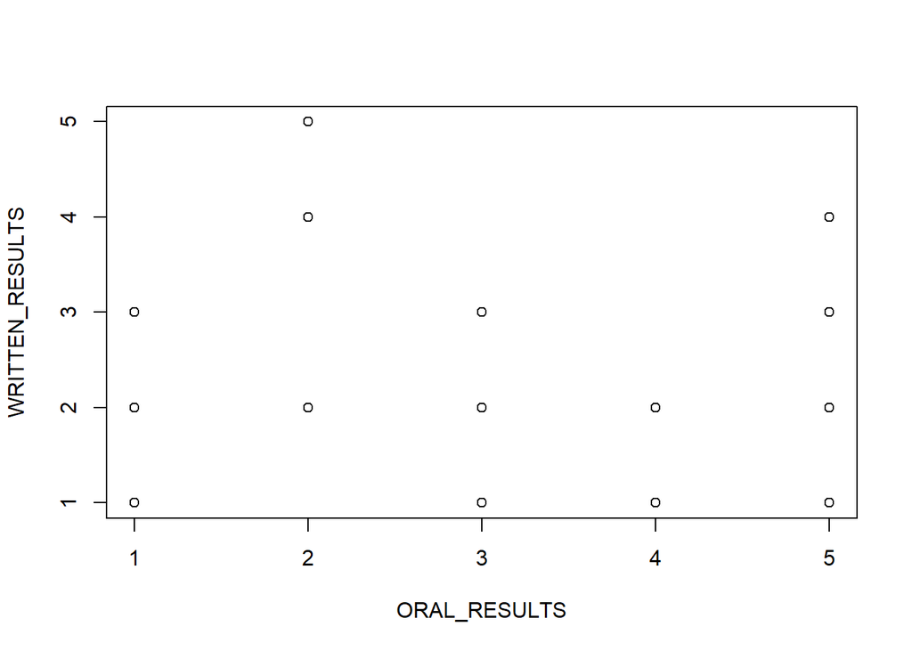

```r
#(b)
plot(ORAL_RESULTS,WRITTEN_RESULTS)
```

```r
cor(ORAL_RESULTS,WRITTEN_RESULTS)
```

```
## [1] -0.1869531
```

```r
cov(ORAL_RESULTS,WRITTEN_RESULTS)
```

```
## [1] -0.3157895
```

```r
#(c)
#There is a negative correlation between oral and written test results.

#(d)
#The correlation between the oral and written test results is low (<0.3) indicating no strong relationship between the two results.
```

# 3.Descriptive Analysis

```r
library(MASS)
library(ISLR)
fix(Auto)

#(a) Below is the list of predictors and thier quantitative/qualitative catergory
#"mpg" - quantitative
#"cylinders" - quantitative
#"displacement" - quantitative
#"horsepower" - quantitative
#"weight" - quantitative
#"acceleration" - quantitative
#"year" - quantitative
#"origin" - qualitative
#"name" - qualitative

#(b)
range(Auto$mpg) #range of 37.6
```

```
## [1]  9.0 46.6
```

```r
range(Auto$cylinders) #range of 5
```

```
## [1] 3 8
```

```r
range(Auto$displacement) #range of 387
```

```
## [1]  68 455
```

```r
range(Auto$horsepower) #range of 184
```

```
## [1]  46 230
```

```r
range(Auto$weight) #range of 3527
```

```
## [1] 1613 5140
```

```r
range(Auto$acceleration)#range of 16.8
```

```
## [1]  8.0 24.8
```

```r
range(Auto$year)#range of 12
```

```
## [1] 70 82
```

```r
#(c)
mean(Auto$mpg)
```

```
## [1] 23.44592
```

```r
sd(Auto$mpg)
```

```
## [1] 7.805007
```

```r
mean(Auto$displacement)
```

```
## [1] 194.412
```

```r
sd(Auto$displacement)
```

```
## [1] 104.644
```

```r
mean(Auto$horsepower)
```

```
## [1] 104.4694
```

```r
sd(Auto$horsepower)
```

```
## [1] 38.49116
```

```r
mean(Auto$weight)
```

```
## [1] 2977.584
```

```r
sd(Auto$weight)
```

```
## [1] 849.4026
```

```r
mean(Auto$acceleration)
```

```
## [1] 15.54133
```

```r
sd(Auto$acceleration)
```

```
## [1] 2.758864
```

```r
mean(Auto$year)
```

```
## [1] 75.97959
```

```r
sd(Auto$year)
```

```
## [1] 3.683737
```

```r
#(d)
Auto_rev <- Auto[-c(10, 85),]

range(Auto_rev$mpg)#range of 37.6
```

```
## [1]  9.0 46.6
```

```r
mean(Auto_rev$mpg)
```

```
## [1] 23.49436
```

```r
sd(Auto_rev$mpg)
```

```
## [1] 7.795198
```

```r
range(Auto_rev$displacement)#range of 387
```

```
## [1]  68 455
```

```r
mean(Auto_rev$displacement)
```

```
## [1] 193.5115
```

```r
sd(Auto_rev$displacement)
```

```
## [1] 104.1407
```

```r
range(Auto_rev$horsepower)#range of 184
```

```
## [1]  46 230
```

```r
mean(Auto_rev$horsepower)
```

```
## [1] 104.0692
```

```r
sd(Auto_rev$horsepower)
```

```
## [1] 38.17633
```

```r
range(Auto_rev$weight)#range of 3527
```

```
## [1] 1613 5140
```

```r
mean(Auto_rev$weight)
```

```
## [1] 2972.469
```

```r
sd(Auto_rev$weight)
```

```
## [1] 848.5121
```

```r
range(Auto_rev$acceleration)#range of 16.8
```

```
## [1]  8.0 24.8
```

```r
mean(Auto_rev$acceleration)
```

```
## [1] 15.5659
```

```r
sd(Auto_rev$acceleration)
```

```
## [1] 2.739672
```

```r
range(Auto_rev$year)#range of 12
```

```
## [1] 70 82
```

```r
mean(Auto_rev$year)
```

```
## [1] 76.00256
```

```r
sd(Auto_rev$year)
```

```
## [1] 3.677556
```

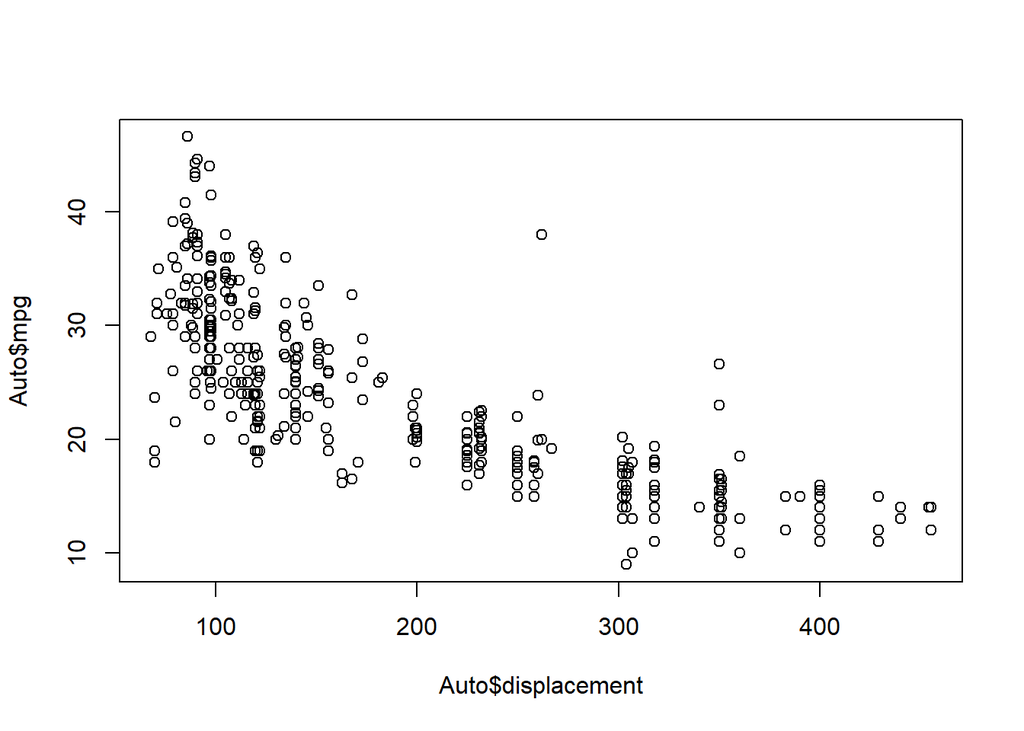

```r
#(e)
plot(Auto$displacement,Auto$mpg)
```

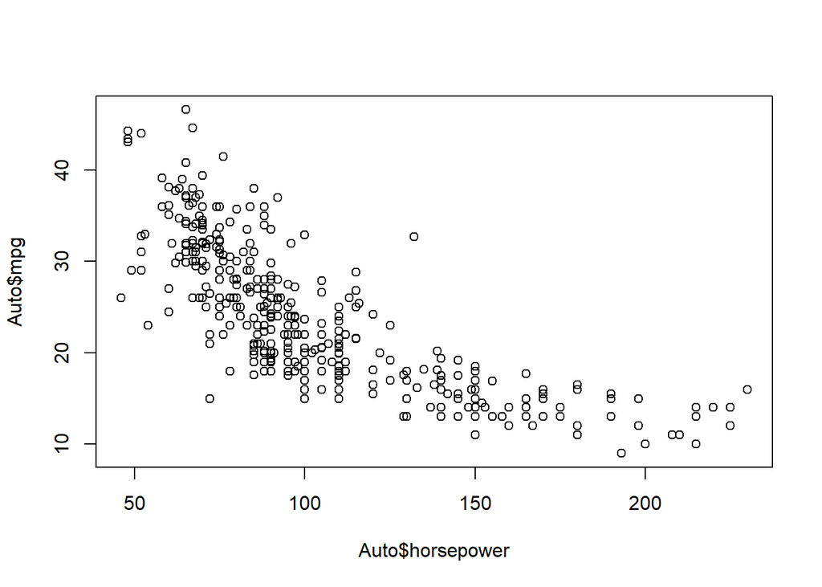

```r
#This plot shows a negative correlation between displacement and mpg.
plot(Auto$horsepower ,Auto$mpg)
```

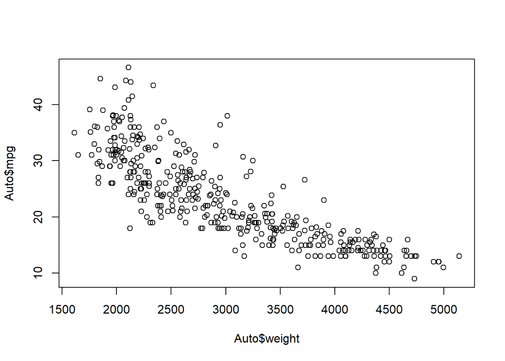

```r
#This plot shows a negative correlation between horsepower and mpg.
plot(Auto$weight,Auto$mpg)
```

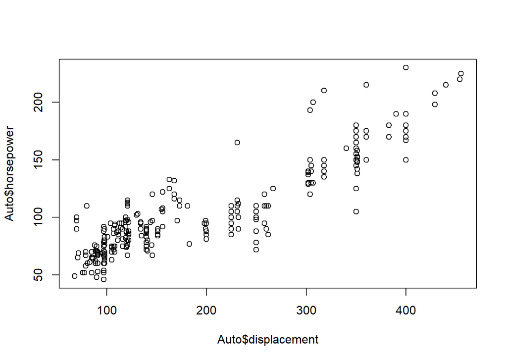

```r
#This plot shows a negative correlation between weight and mpg.
plot(Auto$displacement,Auto$horsepower)
```

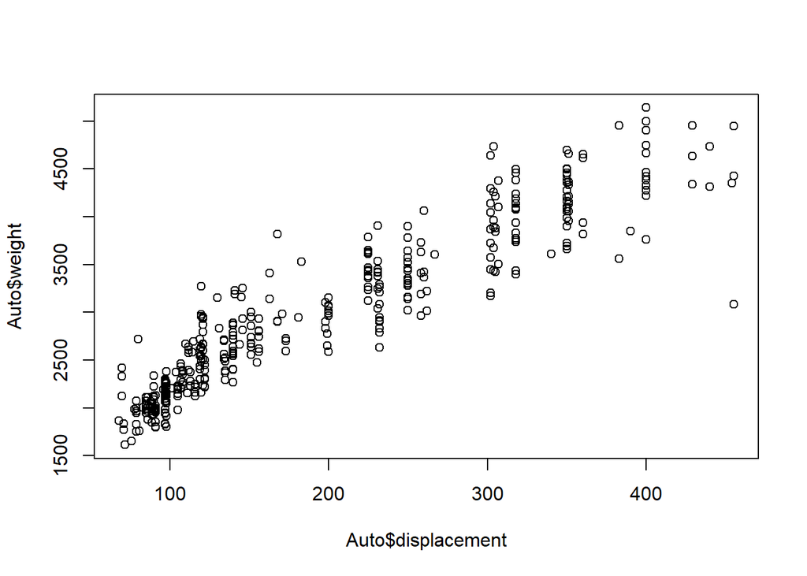

```r
#This plot shows a positive correlation between displacement and horsepower.
plot(Auto$displacement,Auto$weight)
```

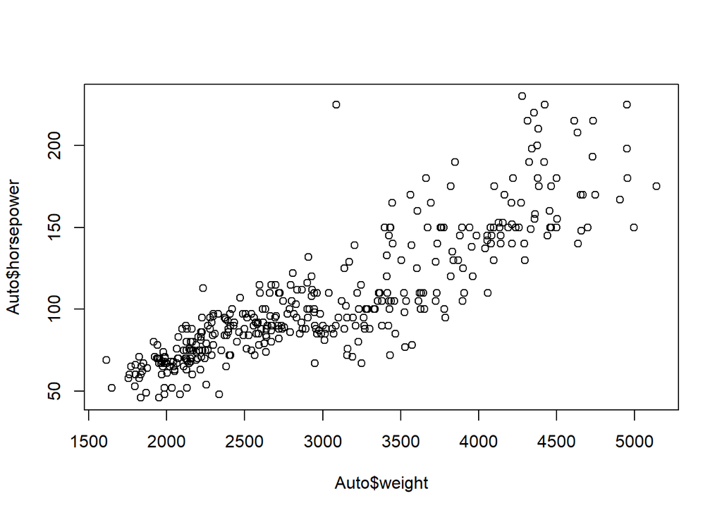

```r
#This plot shows a positive correlation between displacement and weight.
plot(Auto$weight,Auto$horsepower)
```

```r
#This plot shows a positive correlation between weight and horsepower.

#(f)The plots suggest that displacement, horsepower and weight would all be good variables for an mpg prediction model.
```